# How AI Buys Your Oncologist Some Time

AI

Medicine

Bioinformatics

Clinical Trials

Author

James Lindsay

Published

January 21, 2026

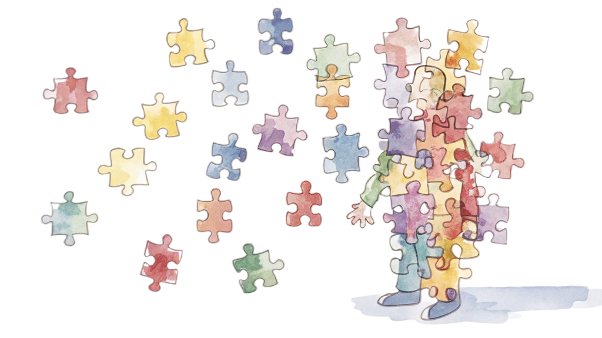

## **The Hidden Geometry of Clinical Trials.**

A patient sits with their oncologist, absorbing the news that their cancer has progressed. They watch as the doctor tabs between a dense electronic medical record, a PDF of genetic test results, and a browser window open to ClinicalTrials.gov.

In the era of precision medicine, an oncologist can sequence a tumor to find a small change in a patient’s genetic code. They can target that mutation with therapies designed at the molecular level. Yet, to find the clinical trial that actually delivers that therapy, the same doctor often relies on a tool that treats the patient’s life story like a shopping list: the keyword search.

This paradox defines modern cancer care. [Ken Kehl](https://edhub.ama-assn.org/jn-learning/audio-player/18983455), an oncologist and data scientist at Dana-Farber, describes the reality of this gap. While the biological understanding of disease has moved into high-definition, the mechanism for connecting patients to cures remains stuck in low-resolution.

“Trials have gotten very granular,” Kehl explains. “They are looking for very specific subpopulations of patients.” A patient’s eligibility for a trial is rarely defined by a single tag like “Lung Cancer”. It is a complex logic puzzle scattered across pathology reports, genomic PDFs, and physician notes, creating an unstructured narrative that defies simple database queries.

For decades, the only processor capable of solving this puzzle was the human brain. Kehl describes the standard of practice as “quite manual and human.” A doctor had to sit down, read the patient’s file, memorize the eligibility criteria of a dozen open trials, and mentally cross-reference them in real-time.

While some patients attempt to act as their own advocates, Kehl notes that “a cancer diagnosis or need for a change in treatment is overwhelming.” In that moment of vulnerability, the burden falls entirely on “the individual doc” to find a path forward. It is a search for a needle in a haystack where the needle and the haystack are rapidly changing.

Now, physician scientists are attempting to solve this by treating clinical trial matching not as a checklist, but as a geometry problem.

Seen this way, trial matching begins to look less like a clinical judgment problem and more like an information discovery problem. By pairing large language models with a paradigm known as “retrieve and re-rank,” researchers have built a system that allows doctors to search for trials using the most natural interface available: the patient’s own story.

On the everyday web, search problems are largely solved. You can search for “running shoes” on Amazon and instantly filter by size, color, and brand because products come with structured tags. But patients don’t have tags; they are biographies composed of their medical, cancer, and personal journeys. A patient’s history might describe symptoms of kidney failure using nuanced narrative language, which standard search tools miss unless a physician explicitly translates those stories into rigid database terms like “renal insufficiency.”

This “translation tax” is what breaks the workflow. Existing tools like ClinicalTrials.gov assume that clinicians will search for trials the way database administrators do: by translating clinical questions into structured queries and predefined fields. But in practice, physicians think in narrative, patient-centered terms. The burden of translating a complex clinical situation into the language of a database has long fallen on them, eating up the precious few minutes they have with the patient.

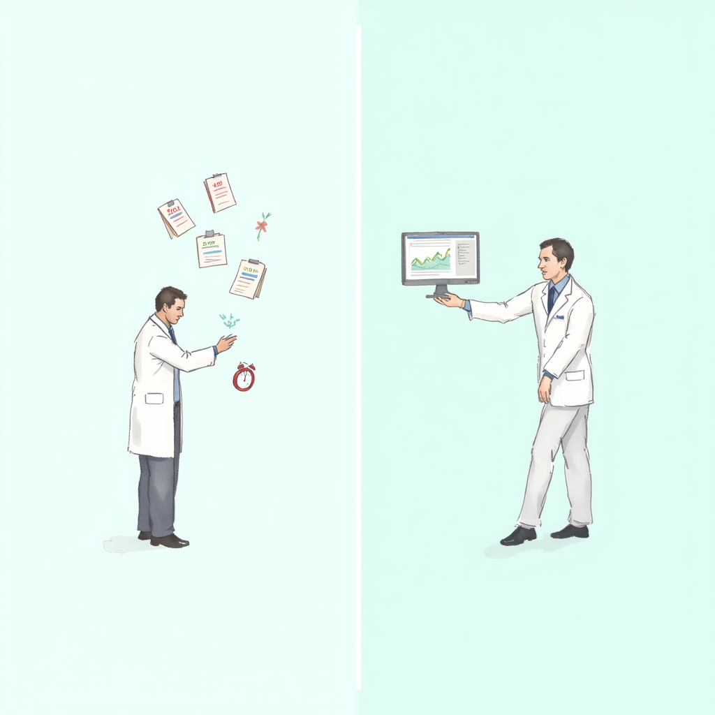

**The Translation Tax.** On the left, the physician carries the cognitive burden of synthesizing unstructured data from scattered sources. On the right, AI acts as a translation layer, ingesting the raw history and presenting a unified, actionable clinical picture. Illustration generated by [ilus.ai](https://ilus.ai/).

Kehl refers to these high-stakes moments as “clinical inflection points”—the specific windows in time when a patient’s cancer is worsening and they “essentially need a change in treatment.”

Often, the full picture of a patient’s health only coalesces when they are sitting in front of their care team. If a clinical trial is to be an option, the physician needs to know about it *in that specific inflection point*. They simply do not have the time to summarize the patient’s history, translate it into database queries, and perform an exhaustive search.

When time is limited, the goal shifts. The priority is no longer to exhaustively prove a patient’s eligibility, but to rapidly surface the most plausible options. This is where the new “retrieve and re-rank” system steps in. By allowing the physician to input a natural language summary and focusing only on key eligibility criteria, the system reframes the task itself: from proving eligibility upfront to prioritizing which possibilities deserve closer human attention.

The arrival of Large Language Models (LLMs) seemed to offer an easy fix. In theory, a system like GPT-4 could read a patient’s file and reason through eligibility criteria just like a human. But researchers at the Dana-Farber Cancer Institute quickly ran into a wall of simple arithmetic: scale. Deep reasoning models are computationally heavy. Asking an LLM to “read” thousands of open clinical trials against a complex patient history in real-time is computationally intractable and prohibitively slow.

To solve this, the Dana-Farber team took a page from the playbook of the world’s biggest search engines. They adopted a two-step architecture known as “retrieve and re-rank.” In this framing, the goal isn’t to have the AI make a final medical judgment, but to rapidly build a short list of high-quality candidates that the physician can review at a glance. This speed buys the physician agency. Because the results appear almost instantly, doctors don’t have to abdicate their responsibility to a black box. They maintain full narrative control, editing the patient summary to address missing data or late-breaking changes in real-time.

The mechanics of this discovery engine rely on a pipeline designed to balance speed with rigor. It begins with an act of translation. An LLM ingests the scattered fragments of a patient’s history—physician notes, pathology reports, genetic tests—and splits them into two distinct data streams.

The first stream is a **clinical summary**: a concise narrative of the patient’s disease trajectory, biomarkers, and treatment history. This “story” is what the system will use to find conceptual neighbors in the clinical landscape. The second is a **boilerplate profile**: a rigid checklist of common “safety constraints” that apply to almost any trial, from renal dysfunction to history of pneumonitis. The system performs this same dual-stream translation on every clinical trial in the database, ensuring that every trial is defined by both its scientific goals and its safety “no-fly list.”

[output not shown]

Figure 1: **The Funnel of Refinement.** The system balances speed and precision. The LLM first translates raw history into a **Clinical Summary** (for broad search) and an **Exclusion Profile** (for safety checks). These streams converge at the final “Judge” step to ensure candidates are both relevant and safe.

Once the patient and the trials speak the same language, the system begins its three-step journey toward a match. The first step translates meaning into geometry.

In traditional search, words are rigid. “Renal failure” and “kidney disease” share no common letters; to a keyword search, they are strangers. But to an AI trained for trial matching, they are conceptual neighbors. The model converts these text summaries into numerical lists called **vector embeddings**.

Think of these embeddings as coordinates on a map of concepts. Just as latitude and longitude pinpoint a city’s location on Earth, an embedding pinpoints a patient’s condition in a high-dimensional mathematical space. In this geometry, distance represents difference. A patient with lung cancer lands in a specific neighborhood of this abstract universe, surrounded by trials that treat lung cancer, while trials for breast cancer or leukemia are pushed to distant galaxies. By turning the patient’s story into a coordinate, the problem shifts from reading text to measuring distance.

[interactive chart not shown]

MDS of patient and several potential trials

Figure 2: **Mapping the Search Space.** Traditional database searches often fail to capture the nuance of a patient’s condition. By encoding medical narratives as vectors in a high-dimensional space, the AI system reveals a hidden geometry: trials that are semantically similar cluster together. In this visualization, the simulated patient (red) is surrounded by their most viable treatment options (green), instantly narrowing the search from thousands of possibilities to a handful of high-probability candidates.

To make this map useful, the researchers customized an open-source model using a technique called contrastive learning. By training the model on thousands of synthetically generated patient-trial pairs, they taught it the geometry of eligibility: adjusting the mathematical landscape so that a patient with a specific mutation lands in the same neighborhood as trials targeting that mutation, while pushing incompatible trials far away. This reliance on synthetic data solved a dual problem: it provided the massive volume of examples deep learning requires, while bypassing the privacy constraints that lock up real medical records.

Finally, the system moves to the “Re-rank” phase, where speed is traded for accuracy. While the vector search is excellent at finding “neighbors,” it is a fuzzy process. To reach clinical-grade precision, the system employs a separate “text-classification” model—heavier and more computationally expensive—to act as a two-stage judge for the top 20 candidates.

In Step 2, this model performs a **narrative scrutiny**. It reads the patient summary against the trial summary, looking for the nuance that vectors might miss. It checks if the patient’s specific biomarker status or treatment history truly aligns with the trial’s scientific intent. If a trial requires a specific “line of therapy” that the patient hasn’t reached yet, the judge de-ranks it.

In Step 3, the model moves to the **safety checkpoint**. This is where it evaluates the “boilerplate” exclusions. It cross-references the patient’s profile against a list of hard medical constraints: Does the patient have a history of pneumonitis or heart failure? Is there evidence of renal or liver dysfunction, or uncontrolled brain metastases? By explicitly checking for these along with HIV, hepatitis, and poor performance status, the system performs a final verification. Because this intense reasoning is limited to only the most promising candidates, the system can deliver a verified, prioritized list in seconds—buying the physician the one thing they need most: time.

At the Dana-Farber Cancer Institute, this theoretical engine has already entered the exam room. In a pilot program at affiliated community clinics, physicians have begun using the system as part of their daily rounds. They start not with a database query, but by reviewing a concise, AI-generated summary of the patient’s situation in plain English. The result is an instant, prioritized list of trials that serves as a starting point for the conversation.

The impact is best measured not in search metrics, but in relief. As one clinician in the pilot put it: “Please don’t take this away from me.” In the high-stakes, time-sensitive conversations between oncologists and patients, simply having credible options visible early enough to discuss them changes the nature of the appointment. It shifts the dynamic from a frantic search for data to a thoughtful consideration of choices.

Perhaps the most significant outcome of this engineering choice is that the tool is not locked behind a proprietary wall. Because the underlying models were trained entirely on synthetic data, they contain no private health information. This allows the researchers to release the models as open-source software, removing the financial barrier for hospitals globally. In a field where the slow pace of recruitment acts as a brake on all of medicine, democratizing access to discovery tools effectively hits the accelerator.

**TipExplore the Matching Engine**

The components of this system have been released for public research:

- **Live Demos:** Experience the [Patient Summarization](https://huggingface.co/spaces/ksg-dfci/MatchMiner-AI-Trial-Search) and [Trial Search](https://huggingface.co/spaces/ksg-dfci/MatchMiner-AI-Patient-Search) interfaces.
- **The Models:** Access the underlying weights for [TrialSpace](https://huggingface.co/ksg-dfci/TrialSpace-1225) (embeddings), [TrialChecker](https://huggingface.co/ksg-dfci/TrialChecker-1225) (narrative matching), and [BoilerplateChecker](https://huggingface.co/ksg-dfci/BoilerplateChecker-1225) (exclusion criteria).

Yet, speed comes with its own shadows. The relevance of any AI suggestion is tethered to the data it sees, and there is a risk that a ranked list of trials might be treated with undue authority, subtly shaping a doctor’s judgment before they have even spoken to the patient. Systematic evaluation remains difficult; clinical workflows vary wildly from the academic halls of Dana-Farber to rural community clinics, and it remains an open question whether this digital efficiency will translate uniformly across the messy reality of global healthcare.

The goal is not to replace the physician’s judgment, but to unburden it. Back in the exam room, the oncologist finishes reviewing the AI-generated list and turns away from the screen. They swivel their chair to look the patient in the eye. “We have some promising options,” they say. In this moment, the machine has quietly reshaped the space in which the decision takes form, clearing the administrative noise so the human connection can take center stage.

Yet, this scene represents a local victory in a much larger war. The true test of this technology lies in whether it can survive the transplant from the Boston to other cancer centers and even the fragmented reality of community oncology. Researchers have begun a rigorous new study to determine if this “retrieve and re-rank” engine merely saves time, or if it actually moves the needle on the metric that matters most: trial participation.